# 131 Final Project

# By: Emma Rosen, Courtney Clement, Brennan Torres

### Importing the data sets/necessary packages:

```python
import pandas as pd
import numpy as np
import seaborn as sns
import matplotlib.pyplot as plt
```

```python
data2015 = pd.read_csv('~/Desktop/2015.csv')
```

# I. Context and description of the data:

## Background information on the subject and the field of study

The other variables in the data set are:

- country
- region
- economic production
- social support
- life expectancy
- freedom
- absense of corruption
- generosity

These columns describe the extent to which these factors contribute in evaluating the happiness in each country. The scoring comes from how the variable in the country compares to the benchmark value of the dystopian society. Dystopia is an imaginary country with the world's least happy people. They have the lowest incomes, life expectancy, etc.

## Information on data collection

a) Who collected the data:

This data set uses date from the Gallup World poll. The scores are based on answers to the main life evaluation question asked in the poll. [1]

b) When the data was collection:

This data was collected in 2015. However, it is an annual report. [1]

c) How the data was collected:

Gallup data is collected either via a one on one interview in developing countries and phone interviews in areas where telephone coverage represents at least 80% of the population. [2]

d) Any implications this may have on analysis:

Considering only some people have the time and resources to complete a 30 minute phone interview, there may be sample biases in place. Additionally, it does not represent the population below the age of 15, so adolescent happiness is not taken into account. However, the Gallup poll is a very thorough and credible measure of world populations and the final forecasts are typically within 2.25 percentage points of the true value. [2]

# II. Exploratory Analysis of the Data

## 1) Summary statistics and the distributional shape of variables

### Initial guilding question: What variables contribute most significantly in predicting a countries overall happiness score.

```python
print(data2015.info())
print(data2015.describe())
```

```
<class 'pandas.core.frame.DataFrame'>
RangeIndex: 158 entries, 0 to 157
Data columns (total 12 columns):
Country                          158 non-null object
Region                           158 non-null object
Happiness Rank                   158 non-null int64
Happiness Score                  158 non-null float64
Standard Error                   158 non-null float64
Economy (GDP per Capita)         158 non-null float64
Family                           158 non-null float64
Health (Life Expectancy)         158 non-null float64
Freedom                          158 non-null float64
Trust (Government Corruption)    158 non-null float64
Generosity                       158 non-null float64
Dystopia Residual                158 non-null float64
dtypes: float64(9), int64(1), object(2)
memory usage: 14.9+ KB
None
       Happiness Rank  Happiness Score  Standard Error  \
count      158.000000       158.000000      158.000000
mean        79.493671         5.375734        0.047885
std         45.754363         1.145010        0.017146
min          1.000000         2.839000        0.018480
25%         40.250000         4.526000        0.037268
50%         79.500000         5.232500        0.043940
75%        118.750000         6.243750        0.052300
max        158.000000         7.587000        0.136930

       Economy (GDP per Capita)      Family  Health (Life Expectancy)  \
count                158.000000  158.000000                158.000000
mean                   0.846137    0.991046                  0.630259
std                    0.403121    0.272369                  0.247078
min                    0.000000    0.000000                  0.000000
25%                    0.545808    0.856823                  0.439185
50%                    0.910245    1.029510                  0.696705
75%                    1.158448    1.214405                  0.811013
max                    1.690420    1.402230                  1.025250

          Freedom  Trust (Government Corruption)  Generosity  \
count  158.000000                     158.000000  158.000000
mean     0.428615                       0.143422    0.237296
std      0.150693                       0.120034    0.126685
min      0.000000                       0.000000    0.000000
25%      0.328330                       0.061675    0.150553
50%      0.435515                       0.107220    0.216130
75%      0.549092                       0.180255    0.309883
max      0.669730                       0.551910    0.795880

       Dystopia Residual
count         158.000000
mean            2.098977
std             0.553550
min             0.328580
25%             1.759410
50%             2.095415
75%             2.462415
max             3.602140
```

How many countries are included in each region:

```python
group_df = data2015.groupby('Region').count()
print(group_df['Country'])
```

```
Region
Australia and New Zealand           2
Central and Eastern Europe         29
Eastern Asia                        6
Latin America and Caribbean        22
Middle East and Northern Africa    20
North America                       2
Southeastern Asia                   9
Southern Asia                       7
Sub-Saharan Africa                 40
Western Europe                     21
Name: Country, dtype: int64
```

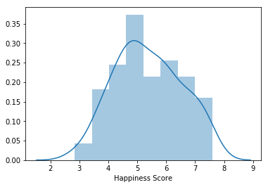

```python
sns.distplot(data2015['Happiness Score'])
```

The distribution of happiness scores is overall a symmetric shape, centered around 5.25 with a range of about 3 to 7.75.

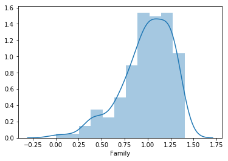

```python
sns.distplot(data2015['Family'])
```

The distribtuion of the family variable scores is left skewed and is centered around 1.125. The range of scores is between 0 and 1.35.

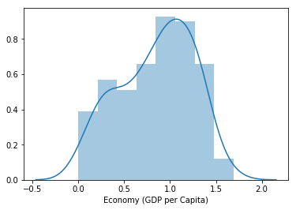

```python
sns.distplot(data2015['Economy (GDP per Capita)'])
```

The distribtution of the economy variable (GDP per Capita) is relatively symmetric and centered around 1. The range of scores is from 0 to 1.7.

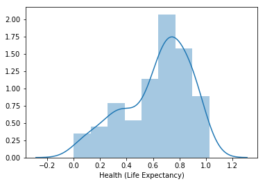

```python
sns.distplot(data2015['Health (Life Expectancy)'])
```

The distribtion of the life expentancy scores is slightly left skewed and centered around .7. The total range of scores are from about 0 to 1.

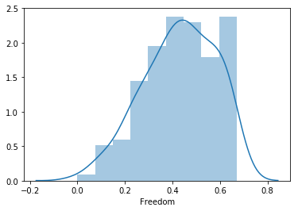

```python
sns.distplot(data2015['Freedom'])
```

The distribution of the freedom scores is slightly left skewed and centered about .4. The range of scores are from about 0 to .7.

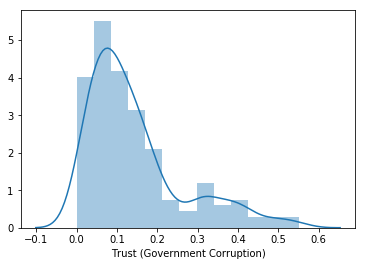

```python
sns.distplot(data2015['Trust (Government Corruption)'])
```

The distribution of the scores for trust (government corruption) is right skewed and centered around .1. The range of scores is about 0 to .55.

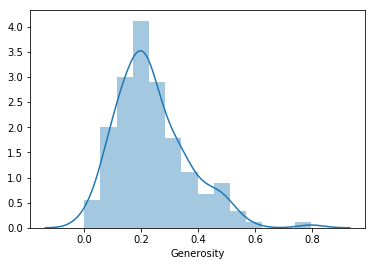

```python
sns.distplot(data2015['Generosity'])
```

The distribution for generosity scores is slightly right skewed and centered around .2. The range of scores is from about 0 to .8.

The pairplot function shows pairwise relationships in the dataset. We can use this to see which variables are strongly correlated.

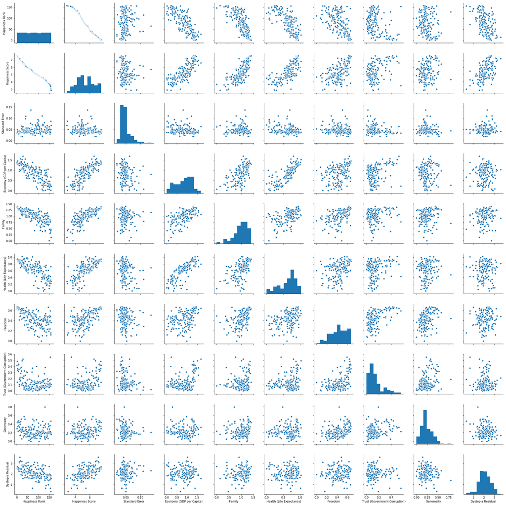

```python
sns.pairplot(data2015)
```

[output not shown]

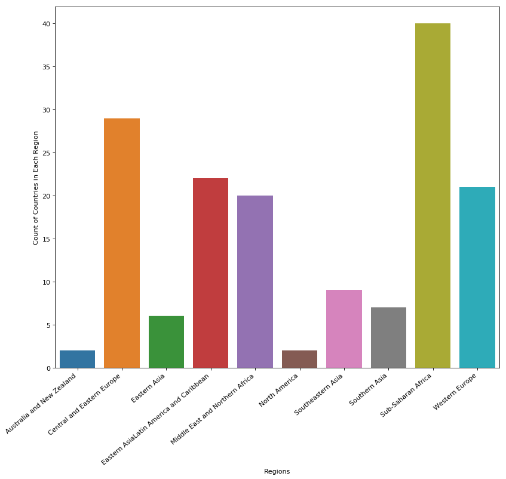

```python
#sns.boxplot(x="Region", y="Happiness Score", data = data2015)
region_count = data2015.groupby('Region', as_index = False).Country.count()
print(region_count)
fig=plt.figure(figsize=(12, 10), dpi= 80, facecolor='w', edgecolor='k')
barplt = sns.barplot(region_count.index, region_count.Country)
plt.xticks([0, 1, 2, 3, 4, 5, 6, 7, 8, 9],['Australia and New Zealand', 'Central and Eastern Europe', 'Eastern Asia', 'Eastern Asia' 'Latin America and Caribbean', 'Middle East and Northern Africa', 'North America', 'Southeastern Asia', 'Southern Asia', 'Sub-Saharan Africa', 'Western Europe'])
plt.xlabel('Regions')
plt.ylabel('Count of Countries in Each Region')
barplt.set_xticklabels(barplt.get_xticklabels(), rotation=40, ha="right")
plt.show()
```

## 2) Unusual features or outliers present in the data

### Checking for outliers for each variable:

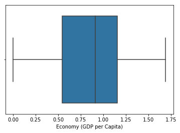

```python
sns.boxplot(x=data2015['Economy (GDP per Capita)'])
```

We can see that there are no outliers in the Economy (GDP per Capita) scores.

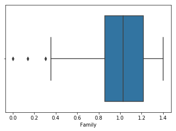

```python
sns.boxplot(x=data2015['Family'])
```

In the family scores, there are three outliers. The three outliers belong to Central African Republic, Togo, and Afghanistan.

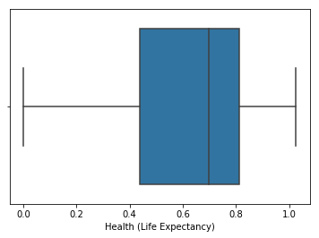

```python
sns.boxplot(x=data2015['Health (Life Expectancy)'])
```

We can see that there are no outliers in the Health (Life Expectancy) scores.

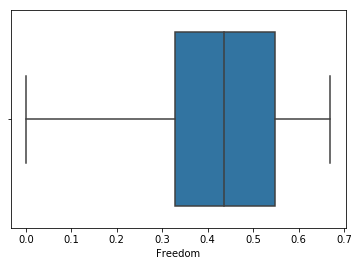

```python
sns.boxplot(x=data2015['Freedom'])
```

We can see that there are no outliers in the Freedom scores.

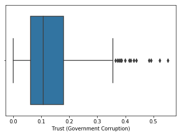

```python
sns.boxplot(x=data2015['Trust (Government Corruption)'])
```

We can see that there are quite a few outliers for the trust (government corruption) score. These countries are Rwanda, Quatar, Singapore, Denmark, Sweden, New Zealand, Switzerland, Finland, Somaliland region, United Arab Emirates, Georgia, Luxembourg, Hong Kong, and Norway. While there are many outliers, for the purpose of our analysis, we want to keep all of these countries in the data set. For this variable specifically, it logically makese sense that there would be a wide range of values/extreme values for the amount that citizens trust or do not trust their government.

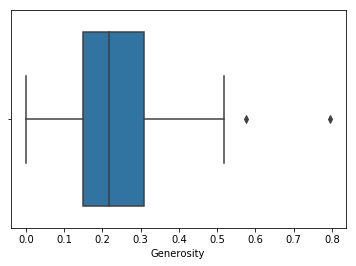

```python
sns.boxplot(x=data2015['Generosity'])
```

There are two outliers for generosity scores. The scores belong to Myanmar and Thailand.

## 3) Potential relationships that may exist in the data

### Scatter plots for the relationship between all 6 variables and happiness score:

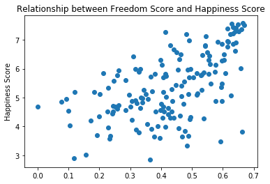

```python
plt.title("Relationship between Freedom Score and Happiness Score")
plt.scatter(x= data2015['Freedom'],y=data2015['Happiness Score'])
plt.xlabel=("Freedom Score")
plt.ylabel("Happiness Score")
plt.show()
```

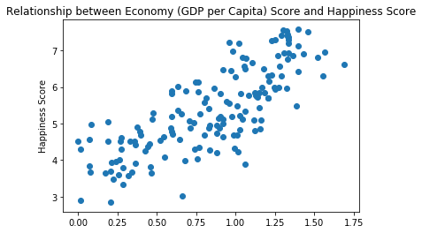

```python
plt.title("Relationship between Economy (GDP per Capita) Score and Happiness Score")
plt.scatter(x= data2015['Economy (GDP per Capita)'],y=data2015['Happiness Score'])
plt.xlabel=("Economy (GDP per Capita) score")
plt.ylabel("Happiness Score")
plt.show()
```

Based on the scatter plot, there is a strong, positive linear correlation between Economy (GDP per capita) score and happiness score.

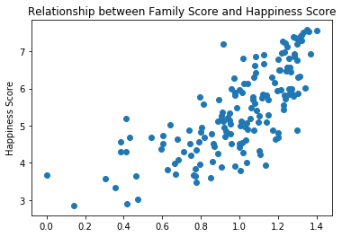

```python
plt.title("Relationship between Family Score and Happiness Score")
plt.scatter(x= data2015['Family'],y=data2015['Happiness Score'])
plt.xlabel=("Family")
plt.ylabel("Happiness Score")
plt.show()
```

Based on the scatter plot, there is a strong, positive linear correlation between family score and happiness score.

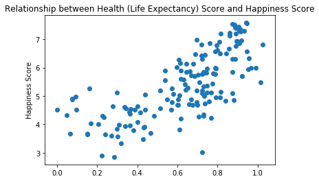

```python
plt.title("Relationship between Health (Life Expectancy) Score and Happiness Score")
plt.scatter(x= data2015['Health (Life Expectancy)'],y=data2015['Happiness Score'])
plt.xlabel=("Health (Life Expectancy) Score")
plt.ylabel("Happiness Score")
plt.show()
```

Based on the scatter plot, there is a strong, positive linear correlation between health (life expectancy score and happiness score.

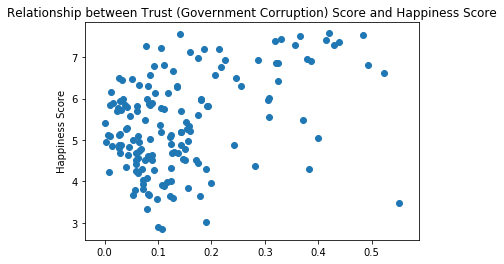

```python
plt.title("Relationship between Trust (Government Corruption) Score and Happiness Score")
plt.scatter(x= data2015['Trust (Government Corruption)'],y=data2015['Happiness Score'])
plt.xlabel=("Trust (Government Corruption)")
plt.ylabel("Happiness Score")
plt.show()
```

Based on the scatter plot, there is not a strong linear correlation between trust (government corruption) score and happiness score.

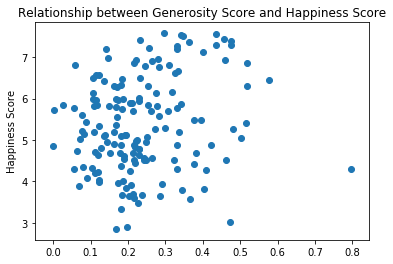

```python
plt.title("Relationship between Generosity Score and Happiness Score")
plt.scatter(x= data2015['Generosity'],y=data2015['Happiness Score'])
plt.xlabel=("Generosity")
plt.ylabel("Happiness Score")
plt.show()
```

Based on the scatter plot, there is not a strong linear correlation between generosity score and happiness score.

From the scatter plots, we would expect freedom, economy, family, and life expectancy to best predict the overall happiness score of a country.

### Finding correlations:

```python
print(data2015[['Happiness Score', 'Economy (GDP per Capita)']].corr())
```

```
                          Happiness Score  Economy (GDP per Capita)
Happiness Score                  1.000000                  0.780966
Economy (GDP per Capita)         0.780966                  1.000000
```

```python
print(data2015[['Happiness Score', 'Family']].corr())
```

```
                 Happiness Score    Family
Happiness Score         1.000000  0.740605
Family                  0.740605  1.000000
```

```python
print(data2015[['Happiness Score', 'Health (Life Expectancy)']].corr())
```

```
                          Happiness Score  Health (Life Expectancy)
Happiness Score                    1.0000                    0.7242
Health (Life Expectancy)           0.7242                    1.0000
```

```python
print(data2015[['Happiness Score', 'Freedom']].corr())
```

```
                 Happiness Score   Freedom
Happiness Score         1.000000  0.568211
Freedom                 0.568211  1.000000
```

```python
print(data2015[['Happiness Score', 'Trust (Government Corruption)']].corr())
```

```
                               Happiness Score  Trust (Government Corruption)
Happiness Score                       1.000000                       0.395199
Trust (Government Corruption)         0.395199                       1.000000
```

```python
print(data2015[['Happiness Score', 'Generosity']].corr())
```

```
                 Happiness Score  Generosity
Happiness Score         1.000000    0.180319
Generosity              0.180319    1.000000
```

After looking at the correlation values, we draw the same conclusions that we did from looking at the scatter plots: we would expect freedom, economy, family, and life expectancy to best predict the overall happiness score of a country.

Correlation with happiness score:

- Economy (GDP per Capita): 0.78
- Family: 0.74
- Health (Life Expectancy): 0.72
- Freedom: 0.57
- Trust (Government Corruption): 0.40
- Generosity: 0.18

# III. Data Modeling

Because each of the variables add up to make the score, we decide to do a bunch of simple linear regressions rather than one multiple linear regression. From the correlation coefficients, we expect that the Economy (GDP per Capita), Family, and Health (Life Expectancy) will be significant.

```python
from sklearn import datasets, linear_model
from sklearn.metrics import mean_squared_error, r2_score
import statsmodels.api as sm
```

## Explanation of the dystopian variable

To be able to to interpret the results of the linear regressions, it is important to understand where the scoring is coming from. The baseline to which countries are compared is a dytopian society. The dystopian society is a combination of the worst scoring countries across all of the variables. For example, if the United States had the worst ecomomy in the world, the dytopian society would take take on the economy of the United States, and so on for each category. Every other country's economy would be scored on how much better it was than that of the United State's, hence all of the scores are positive for all categories and all countries.

To illustrate this further, we took a look at which aspects from which countries make up the dystopian socitey.

#### Country with the lowest economy (GDP per capita):

```python
data2015.loc[data2015['Economy (GDP per Capita)'] == 0]
```

|  | Country | Region | Happiness Rank | Happiness Score | Standard Error | Economy (GDP per Capita) | Family | Health (Life Expectancy) | Freedom | Trust (Government Corruption) | Generosity | Dystopia Residual |
| --- | --- | --- | --- | --- | --- | --- | --- | --- | --- | --- | --- | --- |
| 119 | Congo (Kinshasa) | Sub-Saharan Africa | 120 | 4.517 | 0.0368 | 0.0 | 1.0012 | 0.09806 | 0.22605 | 0.07625 | 0.24834 | 2.86712 |

The dystopian society has the economy of Congo (Kinshasa).

#### Country with the lowest family:

```python
data2015.loc[data2015['Family'] == 0]
```

|  | Country | Region | Happiness Rank | Happiness Score | Standard Error | Economy (GDP per Capita) | Family | Health (Life Expectancy) | Freedom | Trust (Government Corruption) | Generosity | Dystopia Residual |
| --- | --- | --- | --- | --- | --- | --- | --- | --- | --- | --- | --- | --- |
| 147 | Central African Republic | Sub-Saharan Africa | 148 | 3.678 | 0.06112 | 0.0785 | 0.0 | 0.06699 | 0.48879 | 0.08289 | 0.23835 | 2.7223 |

The dystopian society has the family of the Central African Republic.

#### Country with the lowest heath (life expectancy):

```python
data2015.loc[data2015['Health (Life Expectancy)'] == 0]
```

|  | Country | Region | Happiness Rank | Happiness Score | Standard Error | Economy (GDP per Capita) | Family | Health (Life Expectancy) | Freedom | Trust (Government Corruption) | Generosity | Dystopia Residual |
| --- | --- | --- | --- | --- | --- | --- | --- | --- | --- | --- | --- | --- |
| 122 | Sierra Leone | Sub-Saharan Africa | 123 | 4.507 | 0.07068 | 0.33024 | 0.95571 | 0.0 | 0.4084 | 0.08786 | 0.21488 | 2.51009 |

The dystopian society has the health (life expectancy) of Sierra Leone.

#### Country with the lowest freedom:

```python
data2015.loc[data2015['Freedom'] == 0]
```

|  | Country | Region | Happiness Rank | Happiness Score | Standard Error | Economy (GDP per Capita) | Family | Health (Life Expectancy) | Freedom | Trust (Government Corruption) | Generosity | Dystopia Residual |
| --- | --- | --- | --- | --- | --- | --- | --- | --- | --- | --- | --- | --- |
| 111 | Iraq | Middle East and Northern Africa | 112 | 4.677 | 0.05232 | 0.98549 | 0.81889 | 0.60237 | 0.0 | 0.13788 | 0.17922 | 1.95335 |

The dystopian society has the freedom of Iraq.

#### Country with the lowest trust in the government:

```python
data2015.loc[data2015['Trust (Government Corruption)'] == 0]
```

|  | Country | Region | Happiness Rank | Happiness Score | Standard Error | Economy (GDP per Capita) | Family | Health (Life Expectancy) | Freedom | Trust (Government Corruption) | Generosity | Dystopia Residual |
| --- | --- | --- | --- | --- | --- | --- | --- | --- | --- | --- | --- | --- |
| 73 | Indonesia | Southeastern Asia | 74 | 5.399 | 0.02596 | 0.82827 | 1.08708 | 0.63793 | 0.46611 | 0.0 | 0.51535 | 1.86399 |

The dystopian society has the trust in the government of Indonesia.

#### Country with the lowest generosity:

```python
data2015.loc[data2015['Generosity'] == 0]
```

|  | Country | Region | Happiness Rank | Happiness Score | Standard Error | Economy (GDP per Capita) | Family | Health (Life Expectancy) | Freedom | Trust (Government Corruption) | Generosity | Dystopia Residual |
| --- | --- | --- | --- | --- | --- | --- | --- | --- | --- | --- | --- | --- |
| 101 | Greece | Western Europe | 102 | 4.857 | 0.05062 | 1.15406 | 0.92933 | 0.88213 | 0.07699 | 0.01397 | 0.0 | 1.80101 |

The dystopian society has the generosity of Greece.

### Linear regression model comparing the Happiness Score and the Economy of a country:

```python
X = sm.add_constant(data2015["Economy (GDP per Capita)"])
model_economy = sm.OLS(data2015["Happiness Score"], X).fit()
model_economy.summary()
```

OLS Regression Results

| Dep. Variable: | Happiness Score | R-squared: | 0.610 |
| --- | --- | --- | --- |
| Model: | OLS | Adj. R-squared: | 0.607 |
| Method: | Least Squares | F-statistic: | 243.9 |
| Date: | Tue, 12 Jun 2018 | Prob (F-statistic): | 1.05e-33 |
| Time: | 09:03:58 | Log-Likelihood: | -170.72 |
| No. Observations: | 158 | AIC: | 345.4 |
| Df Residuals: | 156 | BIC: | 351.6 |
| Df Model: | 1 |  |  |
| Covariance Type: | nonrobust |  |  |

|  | coef | std err | t | P>\|t\| | [0.025 | 0.975] |
| --- | --- | --- | --- | --- | --- | --- |
| const | 3.4988 | 0.133 | 26.298 | 0.000 | 3.236 | 3.762 |
| Economy (GDP per Capita) | 2.2182 | 0.142 | 15.617 | 0.000 | 1.938 | 2.499 |

| Omnibus: | 1.643 | Durbin-Watson: | 1.103 |
| --- | --- | --- | --- |
| Prob(Omnibus): | 0.440 | Jarque-Bera (JB): | 1.485 |
| Skew: | -0.112 | Prob(JB): | 0.476 |
| Kurtosis: | 2.581 | Cond. No. | 4.45 |

The Model looks like this: Happiness Score = 3.4988 + 2.2182*(Economy (GDP per Capita))

- Bo: When the economy score is zero (the lowest scoring country), we expect the average happiness score to be 3.4988
- B1: If all else is kept constant and we increase the economy score by one unit, we expect the happiness score to increase by 2.2182

### Linear regression model comparing the Happiness Score and the Family Value of a country:

```python
X = sm.add_constant(data2015["Family"])
model_family = sm.OLS(data2015["Happiness Score"], X).fit()
model_family.summary()
```

OLS Regression Results

| Dep. Variable: | Happiness Score | R-squared: | 0.548 |
| --- | --- | --- | --- |
| Model: | OLS | Adj. R-squared: | 0.546 |
| Method: | Least Squares | F-statistic: | 189.5 |
| Date: | Tue, 12 Jun 2018 | Prob (F-statistic): | 9.92e-29 |
| Time: | 09:04:28 | Log-Likelihood: | -182.27 |
| No. Observations: | 158 | AIC: | 368.5 |
| Df Residuals: | 156 | BIC: | 374.7 |
| Df Model: | 1 |  |  |
| Covariance Type: | nonrobust |  |  |

|  | coef | std err | t | P>\|t\| | [0.025 | 0.975] |
| --- | --- | --- | --- | --- | --- | --- |
| const | 2.2902 | 0.232 | 9.855 | 0.000 | 1.831 | 2.749 |
| Family | 3.1134 | 0.226 | 13.766 | 0.000 | 2.667 | 3.560 |

| Omnibus: | 2.999 | Durbin-Watson: | 1.099 |
| --- | --- | --- | --- |
| Prob(Omnibus): | 0.223 | Jarque-Bera (JB): | 2.110 |
| Skew: | -0.089 | Prob(JB): | 0.348 |
| Kurtosis: | 2.463 | Cond. No. | 7.44 |

We can see that there is an R-squared of 0.546, showing that 54.6% of the variance is explained by the family value. We also see that the p-value for the Family variable is approximately 0.000 (or 9.92e-29), which is less than 0.05. Family value is a significant predictor when wanting to predict the happiness of a country.

The Model looks like this: Happiness Score = 2.2902 + 3.1134*(Family)

- Bo: When the family value score is zero (the lowest scoring country), we expect the average happiness score to be 2.2902.
- B1: If all else is kept constant and we increase the family value score by one unit, we expect the happiness score to increase by 3.1134.

### Linear regression model comparing the Happiness Score and the life expectancy of a country:

```python
X = sm.add_constant(data2015["Health (Life Expectancy)"])
model_health = sm.OLS(data2015["Happiness Score"], X).fit()
model_health.summary()
```

OLS Regression Results

| Dep. Variable: | Happiness Score | R-squared: | 0.524 |
| --- | --- | --- | --- |
| Model: | OLS | Adj. R-squared: | 0.521 |
| Method: | Least Squares | F-statistic: | 172.1 |
| Date: | Tue, 12 Jun 2018 | Prob (F-statistic): | 5.79e-27 |
| Time: | 09:04:54 | Log-Likelihood: | -186.36 |
| No. Observations: | 158 | AIC: | 376.7 |
| Df Residuals: | 156 | BIC: | 382.9 |
| Df Model: | 1 |  |  |
| Covariance Type: | nonrobust |  |  |

|  | coef | std err | t | P>\|t\| | [0.025 | 0.975] |
| --- | --- | --- | --- | --- | --- | --- |
| const | 3.2605 | 0.173 | 18.832 | 0.000 | 2.919 | 3.603 |
| Health (Life Expectancy) | 3.3561 | 0.256 | 13.117 | 0.000 | 2.851 | 3.861 |

| Omnibus: | 1.834 | Durbin-Watson: | 1.019 |
| --- | --- | --- | --- |
| Prob(Omnibus): | 0.400 | Jarque-Bera (JB): | 1.862 |
| Skew: | -0.209 | Prob(JB): | 0.394 |
| Kurtosis: | 2.671 | Cond. No. | 5.75 |

We can see that there is an R-squared of 0.524, showing that 52.4% of the variance is explained by the life expectancy. We also see that the p-value for the Health (Life Expecancy) variable is approximately 0.000 (or 5.79e-27), which is less than 0.05. The life expectancy is a significant predictor when wanting to predict the happiness of a country.

The Model looks like this: Happiness Score = 3.2605 + 3.3561*(Health (Life Expectancy))

- Bo: When the life expectancy score is zero (the lowest scoring country), we expect the average happiness score to be 3.2605.
- B1: If all else is kept constant and we increase the life expectancy score by one unit, we expect the happiness score to increase by 3.3561.

### Linear regression model comparing the Happiness Score and the freedom level of the government in a country:

```python
X = sm.add_constant(data2015["Freedom"])
model_freedom = sm.OLS(data2015["Happiness Score"], X).fit()
model_freedom.summary()
```

OLS Regression Results

| Dep. Variable: | Happiness Score | R-squared: | 0.323 |
| --- | --- | --- | --- |
| Model: | OLS | Adj. R-squared: | 0.319 |
| Method: | Least Squares | F-statistic: | 74.38 |
| Date: | Mon, 11 Jun 2018 | Prob (F-statistic): | 6.88e-15 |
| Time: | 13:08:38 | Log-Likelihood: | -214.29 |
| No. Observations: | 158 | AIC: | 432.6 |
| Df Residuals: | 156 | BIC: | 438.7 |
| Df Model: | 1 |  |  |
| Covariance Type: | nonrobust |  |  |

|  | coef | std err | t | P>\|t\| | [0.025 | 0.975] |
| --- | --- | --- | --- | --- | --- | --- |
| const | 3.5252 | 0.227 | 15.505 | 0.000 | 3.076 | 3.974 |
| Freedom | 4.3174 | 0.501 | 8.624 | 0.000 | 3.329 | 5.306 |

| Omnibus: | 5.948 | Durbin-Watson: | 0.608 |
| --- | --- | --- | --- |
| Prob(Omnibus): | 0.051 | Jarque-Bera (JB): | 6.063 |
| Skew: | -0.453 | Prob(JB): | 0.0482 |
| Kurtosis: | 2.686 | Cond. No. | 7.90 |

We can see that there is an R-squared of 0.323, showing that 32.3% of the variance is explained by the freedom level of the country. We also see that the p-value for the trust variable is approximately 0.000, which is less than 0.05. Freedom level of a country is a significant predictor when wanting to predict the happiness of a country.

The Model looks like this: Happiness Score = 3.525 + 4.3174*(Freedom)

- Bo: When the freedom level score is zero (the lowest scoring country), we expect the average happiness score to be 3.525.
- B1: If all else is kept constant and we increase the freedom level score by one unit, we expect the happiness score to increase by 4.3174.

### Linear regression model comparing the Happiness Score and the trust level of the government in a country:

```python
X = sm.add_constant(data2015["Trust (Government Corruption)"])
model_trust = sm.OLS(data2015["Happiness Score"], X).fit()
model_trust.summary()
```

OLS Regression Results

| Dep. Variable: | Happiness Score | R-squared: | 0.156 |
| --- | --- | --- | --- |
| Model: | OLS | Adj. R-squared: | 0.151 |
| Method: | Least Squares | F-statistic: | 28.87 |
| Date: | Tue, 12 Jun 2018 | Prob (F-statistic): | 2.76e-07 |
| Time: | 09:05:24 | Log-Likelihood: | -231.67 |
| No. Observations: | 158 | AIC: | 467.3 |
| Df Residuals: | 156 | BIC: | 473.5 |
| Df Model: | 1 |  |  |
| Covariance Type: | nonrobust |  |  |

|  | coef | std err | t | P>\|t\| | [0.025 | 0.975] |
| --- | --- | --- | --- | --- | --- | --- |
| const | 4.8351 | 0.131 | 36.898 | 0.000 | 4.576 | 5.094 |
| Trust (Government Corruption) | 3.7698 | 0.702 | 5.373 | 0.000 | 2.384 | 5.156 |

| Omnibus: | 3.420 | Durbin-Watson: | 0.275 |
| --- | --- | --- | --- |
| Prob(Omnibus): | 0.181 | Jarque-Bera (JB): | 3.458 |
| Skew: | -0.350 | Prob(JB): | 0.177 |
| Kurtosis: | 2.813 | Cond. No. | 8.53 |

We can see that there is an R-squared of 0.156, showing that 15.6% of the variance is explained by the trust level of the country's government. We also see that the p-value for the trust variable is approximately 0.000 (or 2.76e-07), which is less than 0.05. Trust level of a country's government is a significant predictor when wanting to predict the happiness of a country.

The Model looks like this: Happiness Score = 4.8351 + 3.7698*(Trust (Government Corruption))

- Bo: When the trust level score is zero (the lowest scoring country), we expect the average happiness score to be 4.8351.
- B1: If all else is kept constant and we increase the trust level score by one unit, we expect the happiness score to increase by 3.7698.

### Linear regression model comparing the Happiness Score and the generosity level of the people in a country:

```python
X = sm.add_constant(data2015["Generosity"])
model_generosity = sm.OLS(data2015["Happiness Score"], X).fit()
model_generosity.summary()
```

OLS Regression Results

| Dep. Variable: | Happiness Score | R-squared: | 0.033 |
| --- | --- | --- | --- |
| Model: | OLS | Adj. R-squared: | 0.026 |
| Method: | Least Squares | F-statistic: | 5.243 |
| Date: | Tue, 12 Jun 2018 | Prob (F-statistic): | 0.0234 |
| Time: | 09:06:01 | Log-Likelihood: | -242.47 |
| No. Observations: | 158 | AIC: | 488.9 |
| Df Residuals: | 156 | BIC: | 495.1 |
| Df Model: | 1 |  |  |
| Covariance Type: | nonrobust |  |  |

|  | coef | std err | t | P>\|t\| | [0.025 | 0.975] |
| --- | --- | --- | --- | --- | --- | --- |
| const | 4.9890 | 0.191 | 26.075 | 0.000 | 4.611 | 5.367 |
| Generosity | 1.6298 | 0.712 | 2.290 | 0.023 | 0.224 | 3.036 |

| Omnibus: | 10.635 | Durbin-Watson: | 0.071 |
| --- | --- | --- | --- |
| Prob(Omnibus): | 0.005 | Jarque-Bera (JB): | 4.346 |
| Skew: | -0.062 | Prob(JB): | 0.114 |
| Kurtosis: | 2.197 | Cond. No. | 8.37 |

The Model looks like this: Happiness Score = 4.9890 + 1.6298*(Generosity)

- Bo: When the generosity level score is zero (the lowest scoring country), we expect the average happiness score to be 4.9890.
- B1: If all else is kept constant and we increase the generosity level score by one unit, we expect the happiness score to increase by 1.6298.

## Summary of modeling

We found that overall all of the variables in each of the simple linear regressions were significant, although the generosity variable was the least significant predictor. This means that the perceived generosity level of the people in the country is not as important for determining how happy a country is. It makes sense that all of them would be significant because they help determine the happiness level, although we were hypothesizing that generosity would not be based off of the correlation coefficient (a correlation coefficient of 0.18). Overall, though, we can see that the trust, generosity, freedom, health, family value, and economic status of a country are all significant predictors when predicting the happiness level of a country.

# Citations and References

- [1] https://www.kaggle.com/unsdsn/world-happiness
- [2] http://www.gallup.com/178667/gallup-world-poll-work.aspx